# Risk Factor Analysis

## Outcome Variable

**Outcome Variable:** ever_stunted

## Predictor Variables

**Intervention Variable:** vagbrth

**Adjustment Set:**

unadjusted

## Stratifying Variables

The analysis was stratified on these variable(s):

- agecat
- studyid
- country

## Data Summary

| agecat | studyid | country | vagbrth | ever_stunted | n_cell | n |
| --- | --- | --- | --- | --- | --- | --- |
| 0-6 months | ki1000108-CMC-V-BCS-2002 | INDIA | 0 | 0 | 20 | 368 |
| 0-6 months | ki1000108-CMC-V-BCS-2002 | INDIA | 0 | 1 | 5 | 368 |
| 0-6 months | ki1000108-CMC-V-BCS-2002 | INDIA | 1 | 0 | 272 | 368 |
| 0-6 months | ki1000108-CMC-V-BCS-2002 | INDIA | 1 | 1 | 71 | 368 |
| 0-6 months | ki1000108-IRC | INDIA | 0 | 0 | 59 | 410 |
| 0-6 months | ki1000108-IRC | INDIA | 0 | 1 | 11 | 410 |
| 0-6 months | ki1000108-IRC | INDIA | 1 | 0 | 301 | 410 |
| 0-6 months | ki1000108-IRC | INDIA | 1 | 1 | 39 | 410 |
| 0-6 months | ki1017093b-PROVIDE | BANGLADESH | 0 | 0 | 143 | 700 |
| 0-6 months | ki1017093b-PROVIDE | BANGLADESH | 0 | 1 | 17 | 700 |
| 0-6 months | ki1017093b-PROVIDE | BANGLADESH | 1 | 0 | 491 | 700 |
| 0-6 months | ki1017093b-PROVIDE | BANGLADESH | 1 | 1 | 49 | 700 |
| 0-6 months | ki1017093c-NIH-Crypto | BANGLADESH | 0 | 0 | 175 | 500 |
| 0-6 months | ki1017093c-NIH-Crypto | BANGLADESH | 0 | 1 | 29 | 500 |
| 0-6 months | ki1017093c-NIH-Crypto | BANGLADESH | 1 | 0 | 257 | 500 |
| 0-6 months | ki1017093c-NIH-Crypto | BANGLADESH | 1 | 1 | 39 | 500 |
| 0-6 months | ki1066203-TanzaniaChild2 | TANZANIA, UNITED REPUBLIC OF | 0 | 0 | 192 | 2367 |
| 0-6 months | ki1066203-TanzaniaChild2 | TANZANIA, UNITED REPUBLIC OF | 0 | 1 | 20 | 2367 |
| 0-6 months | ki1066203-TanzaniaChild2 | TANZANIA, UNITED REPUBLIC OF | 1 | 0 | 2015 | 2367 |
| 0-6 months | ki1066203-TanzaniaChild2 | TANZANIA, UNITED REPUBLIC OF | 1 | 1 | 140 | 2367 |
| 0-6 months | ki1119695-PROBIT | BELARUS | 0 | 0 | 1934 | 16893 |
| 0-6 months | ki1119695-PROBIT | BELARUS | 0 | 1 | 17 | 16893 |
| 0-6 months | ki1119695-PROBIT | BELARUS | 1 | 0 | 14806 | 16893 |
| 0-6 months | ki1119695-PROBIT | BELARUS | 1 | 1 | 136 | 16893 |
| 0-6 months | ki1126311-ZVITAMBO | ZIMBABWE | 0 | 0 | 1086 | 13937 |
| 0-6 months | ki1126311-ZVITAMBO | ZIMBABWE | 0 | 1 | 90 | 13937 |
| 0-6 months | ki1126311-ZVITAMBO | ZIMBABWE | 1 | 0 | 11394 | 13937 |
| 0-6 months | ki1126311-ZVITAMBO | ZIMBABWE | 1 | 1 | 1367 | 13937 |
| 0-6 months | kiGH5241-JiVitA-3 | BANGLADESH | 0 | 0 | 1176 | 27088 |
| 0-6 months | kiGH5241-JiVitA-3 | BANGLADESH | 0 | 1 | 337 | 27088 |

[output cut: 78 more lines]

The following strata were considered:

- agecat: 0-24 months, studyid: ki1000108-CMC-V-BCS-2002, country: INDIA
- agecat: 0-24 months, studyid: ki1000108-IRC, country: INDIA
- agecat: 0-24 months, studyid: ki1017093b-PROVIDE, country: BANGLADESH
- agecat: 0-24 months, studyid: ki1017093c-NIH-Crypto, country: BANGLADESH
- agecat: 0-24 months, studyid: ki1066203-TanzaniaChild2, country: TANZANIA, UNITED REPUBLIC OF
- agecat: 0-24 months, studyid: ki1119695-PROBIT, country: BELARUS
- agecat: 0-24 months, studyid: ki1126311-ZVITAMBO, country: ZIMBABWE
- agecat: 0-24 months, studyid: kiGH5241-JiVitA-3, country: BANGLADESH
- agecat: 0-24 months, studyid: kiGH5241-JiVitA-4, country: BANGLADESH
- agecat: 0-6 months, studyid: ki1000108-CMC-V-BCS-2002, country: INDIA
- agecat: 0-6 months, studyid: ki1000108-IRC, country: INDIA
- agecat: 0-6 months, studyid: ki1017093b-PROVIDE, country: BANGLADESH
- agecat: 0-6 months, studyid: ki1017093c-NIH-Crypto, country: BANGLADESH
- agecat: 0-6 months, studyid: ki1066203-TanzaniaChild2, country: TANZANIA, UNITED REPUBLIC OF
- agecat: 0-6 months, studyid: ki1119695-PROBIT, country: BELARUS
- agecat: 0-6 months, studyid: ki1126311-ZVITAMBO, country: ZIMBABWE
- agecat: 0-6 months, studyid: kiGH5241-JiVitA-3, country: BANGLADESH
- agecat: 0-6 months, studyid: kiGH5241-JiVitA-4, country: BANGLADESH
- agecat: 6-24 months, studyid: ki1000108-CMC-V-BCS-2002, country: INDIA
- agecat: 6-24 months, studyid: ki1000108-IRC, country: INDIA
- agecat: 6-24 months, studyid: ki1017093b-PROVIDE, country: BANGLADESH
- agecat: 6-24 months, studyid: ki1017093c-NIH-Crypto, country: BANGLADESH
- agecat: 6-24 months, studyid: ki1066203-TanzaniaChild2, country: TANZANIA, UNITED REPUBLIC OF
- agecat: 6-24 months, studyid: ki1119695-PROBIT, country: BELARUS
- agecat: 6-24 months, studyid: ki1126311-ZVITAMBO, country: ZIMBABWE
- agecat: 6-24 months, studyid: kiGH5241-JiVitA-3, country: BANGLADESH
- agecat: 6-24 months, studyid: kiGH5241-JiVitA-4, country: BANGLADESH

### Dropped Strata

Some strata were dropped due to rare outcomes:

- agecat: 0-24 months, studyid: ki1000108-CMC-V-BCS-2002, country: INDIA

## Methods Detail

We’re interested in the causal parameters $E[Y_a]$ for all values of $a \in \mathcal{A}$. These parameters represent the mean outcome if, possibly contrary to fact, we intervened to set all units to have $A=a$. Under the randomization and positivity assumptions, these are identified by the statistical parameters $\psi_a=E_W[E_{Y|A,W}(Y|A=a,W)]$. In addition, we’re interested in the mean of $Y$, $E[Y]$ under no intervention (the observed mean). We will estimate these parameters by using SuperLearner to fit the relevant likelihood factors – $E_{Y|A,W}(Y|A=a,W)$ and $p(A=a|W)$, and then updating our likelihood fit using a joint TMLE.

For unadjusted analyses ($W=\{\}$), initial likelihoods were estimated using Lrnr_glm to estimate the simple $E(Y|A)$ and Lrnr_mean to estimate $p(A)$. For adjusted analyses, a small library containing Lrnr_glmnet, Lrnr_xgboost, and Lrnr_mean was used.

Having estimated these parameters, we will then use the delta method to estimate relative risks and attributable risks relative to a prespecified baseline level of $A$.

# Results Detail

## Results Plots

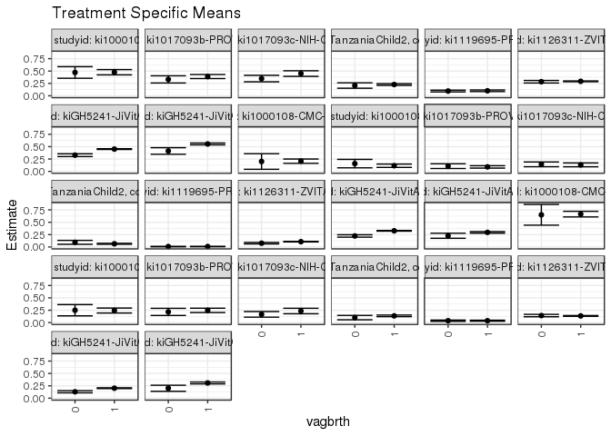

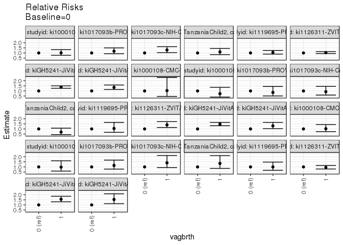

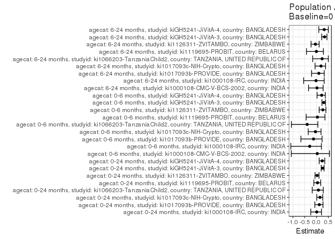

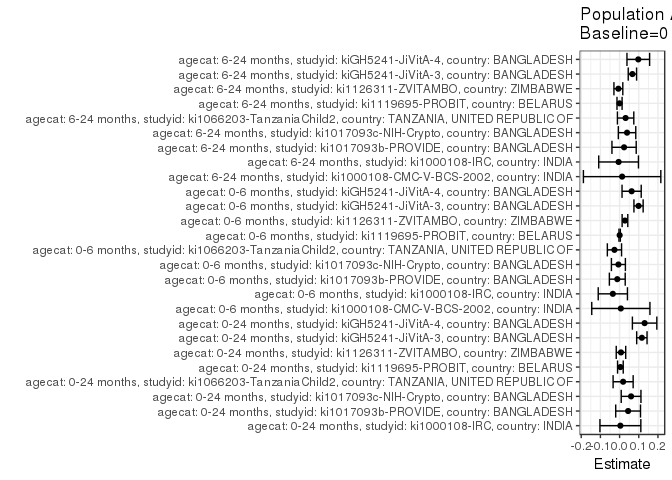

## Results Table

### Parameter: TSM

| agecat | studyid | country | intervention_level | baseline_level | estimate | ci_lower | ci_upper |
| --- | --- | --- | --- | --- | --- | --- | --- |
| 0-24 months | ki1000108-IRC | INDIA | 0 | NA | 0.4714286 | 0.3543468 | 0.5885103 |
| 0-24 months | ki1000108-IRC | INDIA | 1 | NA | 0.4764706 | 0.4233176 | 0.5296236 |
| 0-24 months | ki1017093b-PROVIDE | BANGLADESH | 0 | NA | 0.3312500 | 0.2582692 | 0.4042308 |
| 0-24 months | ki1017093b-PROVIDE | BANGLADESH | 1 | NA | 0.3888889 | 0.3477422 | 0.4300355 |
| 0-24 months | ki1017093c-NIH-Crypto | BANGLADESH | 0 | NA | 0.3480392 | 0.2826069 | 0.4134716 |
| 0-24 months | ki1017093c-NIH-Crypto | BANGLADESH | 1 | NA | 0.4493243 | 0.3926006 | 0.5060481 |
| 0-24 months | ki1066203-TanzaniaChild2 | TANZANIA, UNITED REPUBLIC OF | 0 | NA | 0.2075472 | 0.1529441 | 0.2621502 |
| 0-24 months | ki1066203-TanzaniaChild2 | TANZANIA, UNITED REPUBLIC OF | 1 | NA | 0.2278422 | 0.2101295 | 0.2455550 |
| 0-24 months | ki1119695-PROBIT | BELARUS | 0 | NA | 0.0963608 | 0.0781856 | 0.1145361 |
| 0-24 months | ki1119695-PROBIT | BELARUS | 1 | NA | 0.1011642 | 0.0848093 | 0.1175191 |
| 0-24 months | ki1126311-ZVITAMBO | ZIMBABWE | 0 | NA | 0.2846219 | 0.2588422 | 0.3104016 |
| 0-24 months | ki1126311-ZVITAMBO | ZIMBABWE | 1 | NA | 0.2925436 | 0.2846564 | 0.3004309 |
| 0-24 months | kiGH5241-JiVitA-3 | BANGLADESH | 0 | NA | 0.3276090 | 0.2998306 | 0.3553874 |
| 0-24 months | kiGH5241-JiVitA-3 | BANGLADESH | 1 | NA | 0.4506349 | 0.4430078 | 0.4582620 |
| 0-24 months | kiGH5241-JiVitA-4 | BANGLADESH | 0 | NA | 0.4123989 | 0.3460056 | 0.4787922 |
| 0-24 months | kiGH5241-JiVitA-4 | BANGLADESH | 1 | NA | 0.5545915 | 0.5361395 | 0.5730434 |
| 0-6 months | ki1000108-CMC-V-BCS-2002 | INDIA | 0 | NA | 0.2000000 | 0.0429894 | 0.3570106 |
| 0-6 months | ki1000108-CMC-V-BCS-2002 | INDIA | 1 | NA | 0.2069971 | 0.1640621 | 0.2499321 |
| 0-6 months | ki1000108-IRC | INDIA | 0 | NA | 0.1571429 | 0.0717830 | 0.2425027 |
| 0-6 months | ki1000108-IRC | INDIA | 1 | NA | 0.1147059 | 0.0807922 | 0.1486196 |
| 0-6 months | ki1017093b-PROVIDE | BANGLADESH | 0 | NA | 0.1062500 | 0.0584673 | 0.1540327 |
| 0-6 months | ki1017093b-PROVIDE | BANGLADESH | 1 | NA | 0.0907407 | 0.0664966 | 0.1149849 |
| 0-6 months | ki1017093c-NIH-Crypto | BANGLADESH | 0 | NA | 0.1421569 | 0.0941884 | 0.1901253 |
| 0-6 months | ki1017093c-NIH-Crypto | BANGLADESH | 1 | NA | 0.1317568 | 0.0931872 | 0.1703263 |
| 0-6 months | ki1066203-TanzaniaChild2 | TANZANIA, UNITED REPUBLIC OF | 0 | NA | 0.0943396 | 0.0549845 | 0.1336948 |
| 0-6 months | ki1066203-TanzaniaChild2 | TANZANIA, UNITED REPUBLIC OF | 1 | NA | 0.0649652 | 0.0545571 | 0.0753733 |
| 0-6 months | ki1119695-PROBIT | BELARUS | 0 | NA | 0.0087135 | 0.0045803 | 0.0128466 |
| 0-6 months | ki1119695-PROBIT | BELARUS | 1 | NA | 0.0091019 | 0.0058078 | 0.0123959 |
| 0-6 months | ki1126311-ZVITAMBO | ZIMBABWE | 0 | NA | 0.0765306 | 0.0613360 | 0.0917252 |
| 0-6 months | ki1126311-ZVITAMBO | ZIMBABWE | 1 | NA | 0.1071233 | 0.1017572 | 0.1124894 |
| 0-6 months | kiGH5241-JiVitA-3 | BANGLADESH | 0 | NA | 0.2227363 | 0.1984007 | 0.2470719 |
| 0-6 months | kiGH5241-JiVitA-3 | BANGLADESH | 1 | NA | 0.3274291 | 0.3204639 | 0.3343944 |
| 0-6 months | kiGH5241-JiVitA-4 | BANGLADESH | 0 | NA | 0.2270270 | 0.1760489 | 0.2780052 |
| 0-6 months | kiGH5241-JiVitA-4 | BANGLADESH | 1 | NA | 0.2954545 | 0.2791765 | 0.3117326 |
| 6-24 months | ki1000108-CMC-V-BCS-2002 | INDIA | 0 | NA | 0.6500000 | 0.4405988 | 0.8594012 |
| 6-24 months | ki1000108-CMC-V-BCS-2002 | INDIA | 1 | NA | 0.6641791 | 0.6075379 | 0.7208203 |
| 6-24 months | ki1000108-IRC | INDIA | 0 | NA | 0.2500000 | 0.1364215 | 0.3635785 |
| 6-24 months | ki1000108-IRC | INDIA | 1 | NA | 0.2438163 | 0.1937158 | 0.2939167 |
| 6-24 months | ki1017093b-PROVIDE | BANGLADESH | 0 | NA | 0.2160000 | 0.1437870 | 0.2882130 |
| 6-24 months | ki1017093b-PROVIDE | BANGLADESH | 1 | NA | 0.2473118 | 0.2034240 | 0.2911996 |
| 6-24 months | ki1017093c-NIH-Crypto | BANGLADESH | 0 | NA | 0.1666667 | 0.1102407 | 0.2230926 |
| 6-24 months | ki1017093c-NIH-Crypto | BANGLADESH | 1 | NA | 0.2345133 | 0.1792040 | 0.2898226 |
| 6-24 months | ki1066203-TanzaniaChild2 | TANZANIA, UNITED REPUBLIC OF | 0 | NA | 0.1011236 | 0.0568206 | 0.1454266 |
| 6-24 months | ki1066203-TanzaniaChild2 | TANZANIA, UNITED REPUBLIC OF | 1 | NA | 0.1359223 | 0.1193719 | 0.1524728 |
| 6-24 months | ki1119695-PROBIT | BELARUS | 0 | NA | 0.0382369 | 0.0250613 | 0.0514124 |
| 6-24 months | ki1119695-PROBIT | BELARUS | 1 | NA | 0.0380028 | 0.0277925 | 0.0482131 |
| 6-24 months | ki1126311-ZVITAMBO | ZIMBABWE | 0 | NA | 0.1419598 | 0.1177132 | 0.1662064 |
| 6-24 months | ki1126311-ZVITAMBO | ZIMBABWE | 1 | NA | 0.1350231 | 0.1277331 | 0.1423131 |
| 6-24 months | kiGH5241-JiVitA-3 | BANGLADESH | 0 | NA | 0.1300728 | 0.1077131 | 0.1524326 |
| 6-24 months | kiGH5241-JiVitA-3 | BANGLADESH | 1 | NA | 0.2021996 | 0.1938738 | 0.2105254 |
| 6-24 months | kiGH5241-JiVitA-4 | BANGLADESH | 0 | NA | 0.2006173 | 0.1391792 | 0.2620554 |
| 6-24 months | kiGH5241-JiVitA-4 | BANGLADESH | 1 | NA | 0.3078576 | 0.2887519 | 0.3269633 |

### Parameter: E(Y)

| agecat | studyid | country | intervention_level | baseline_level | estimate | ci_lower | ci_upper |
| --- | --- | --- | --- | --- | --- | --- | --- |
| 0-24 months | ki1000108-IRC | INDIA | NA | NA | 0.4756098 | 0.4272105 | 0.5240091 |
| 0-24 months | ki1017093b-PROVIDE | BANGLADESH | NA | NA | 0.3757143 | 0.3398113 | 0.4116172 |
| 0-24 months | ki1017093c-NIH-Crypto | BANGLADESH | NA | NA | 0.4080000 | 0.3648790 | 0.4511210 |
| 0-24 months | ki1066203-TanzaniaChild2 | TANZANIA, UNITED REPUBLIC OF | NA | NA | 0.2260245 | 0.2091713 | 0.2428777 |
| 0-24 months | ki1119695-PROBIT | BELARUS | NA | NA | 0.1006096 | 0.0848963 | 0.1163228 |
| 0-24 months | ki1126311-ZVITAMBO | ZIMBABWE | NA | NA | 0.2918756 | 0.2843333 | 0.2994180 |
| 0-24 months | kiGH5241-JiVitA-3 | BANGLADESH | NA | NA | 0.4437641 | 0.4362380 | 0.4512902 |
| 0-24 months | kiGH5241-JiVitA-4 | BANGLADESH | NA | NA | 0.5429204 | 0.5251795 | 0.5606613 |
| 0-6 months | ki1000108-CMC-V-BCS-2002 | INDIA | NA | NA | 0.2065217 | 0.1651060 | 0.2479375 |
| 0-6 months | ki1000108-IRC | INDIA | NA | NA | 0.1219512 | 0.0902381 | 0.1536643 |
| 0-6 months | ki1017093b-PROVIDE | BANGLADESH | NA | NA | 0.0942857 | 0.0726222 | 0.1159492 |
| 0-6 months | ki1017093c-NIH-Crypto | BANGLADESH | NA | NA | 0.1360000 | 0.1059237 | 0.1660763 |
| 0-6 months | ki1066203-TanzaniaChild2 | TANZANIA, UNITED REPUBLIC OF | NA | NA | 0.0675961 | 0.0574802 | 0.0777120 |
| 0-6 months | ki1119695-PROBIT | BELARUS | NA | NA | 0.0090570 | 0.0059070 | 0.0122070 |
| 0-6 months | ki1126311-ZVITAMBO | ZIMBABWE | NA | NA | 0.1045419 | 0.0994621 | 0.1096217 |
| 0-6 months | kiGH5241-JiVitA-3 | BANGLADESH | NA | NA | 0.3215815 | 0.3148000 | 0.3283630 |
| 0-6 months | kiGH5241-JiVitA-4 | BANGLADESH | NA | NA | 0.2898358 | 0.2745243 | 0.3051473 |
| 6-24 months | ki1000108-CMC-V-BCS-2002 | INDIA | NA | NA | 0.6631944 | 0.6085159 | 0.7178730 |
| 6-24 months | ki1000108-IRC | INDIA | NA | NA | 0.2448378 | 0.1989973 | 0.2906782 |
| 6-24 months | ki1017093b-PROVIDE | BANGLADESH | NA | NA | 0.2394366 | 0.2018814 | 0.2769918 |
| 6-24 months | ki1017093c-NIH-Crypto | BANGLADESH | NA | NA | 0.2055838 | 0.1656288 | 0.2455387 |
| 6-24 months | ki1066203-TanzaniaChild2 | TANZANIA, UNITED REPUBLIC OF | NA | NA | 0.1325301 | 0.1169740 | 0.1480862 |
| 6-24 months | ki1119695-PROBIT | BELARUS | NA | NA | 0.0380298 | 0.0285924 | 0.0474672 |
| 6-24 months | ki1126311-ZVITAMBO | ZIMBABWE | NA | NA | 0.1356207 | 0.1286388 | 0.1426026 |
| 6-24 months | kiGH5241-JiVitA-3 | BANGLADESH | NA | NA | 0.1969628 | 0.1889381 | 0.2049875 |
| 6-24 months | kiGH5241-JiVitA-4 | BANGLADESH | NA | NA | 0.2981575 | 0.2800007 | 0.3163142 |

### Parameter: RR

| agecat | studyid | country | intervention_level | baseline_level | estimate | ci_lower | ci_upper |
| --- | --- | --- | --- | --- | --- | --- | --- |
| 0-24 months | ki1000108-IRC | INDIA | 0 | 0 | 1.0000000 | 1.0000000 | 1.000000 |
| 0-24 months | ki1000108-IRC | INDIA | 1 | 0 | 1.0106952 | 0.7698030 | 1.326969 |
| 0-24 months | ki1017093b-PROVIDE | BANGLADESH | 0 | 0 | 1.0000000 | 1.0000000 | 1.000000 |
| 0-24 months | ki1017093b-PROVIDE | BANGLADESH | 1 | 0 | 1.1740042 | 0.9194423 | 1.499046 |
| 0-24 months | ki1017093c-NIH-Crypto | BANGLADESH | 0 | 0 | 1.0000000 | 1.0000000 | 1.000000 |
| 0-24 months | ki1017093c-NIH-Crypto | BANGLADESH | 1 | 0 | 1.2910164 | 1.0293979 | 1.619124 |
| 0-24 months | ki1066203-TanzaniaChild2 | TANZANIA, UNITED REPUBLIC OF | 0 | 0 | 1.0000000 | 1.0000000 | 1.000000 |
| 0-24 months | ki1066203-TanzaniaChild2 | TANZANIA, UNITED REPUBLIC OF | 1 | 0 | 1.0977853 | 0.8344032 | 1.444305 |
| 0-24 months | ki1119695-PROBIT | BELARUS | 0 | 0 | 1.0000000 | 1.0000000 | 1.000000 |
| 0-24 months | ki1119695-PROBIT | BELARUS | 1 | 0 | 1.0498475 | 0.8855095 | 1.244684 |
| 0-24 months | ki1126311-ZVITAMBO | ZIMBABWE | 0 | 0 | 1.0000000 | 1.0000000 | 1.000000 |
| 0-24 months | ki1126311-ZVITAMBO | ZIMBABWE | 1 | 0 | 1.0278324 | 0.9351479 | 1.129703 |
| 0-24 months | kiGH5241-JiVitA-3 | BANGLADESH | 0 | 0 | 1.0000000 | 1.0000000 | 1.000000 |
| 0-24 months | kiGH5241-JiVitA-3 | BANGLADESH | 1 | 0 | 1.3755267 | 1.2620751 | 1.499177 |
| 0-24 months | kiGH5241-JiVitA-4 | BANGLADESH | 0 | 0 | 1.0000000 | 1.0000000 | 1.000000 |
| 0-24 months | kiGH5241-JiVitA-4 | BANGLADESH | 1 | 0 | 1.3447937 | 1.1408040 | 1.585259 |
| 0-6 months | ki1000108-CMC-V-BCS-2002 | INDIA | 0 | 0 | 1.0000000 | 1.0000000 | 1.000000 |
| 0-6 months | ki1000108-CMC-V-BCS-2002 | INDIA | 1 | 0 | 1.0349854 | 0.4595055 | 2.331190 |
| 0-6 months | ki1000108-IRC | INDIA | 0 | 0 | 1.0000000 | 1.0000000 | 1.000000 |
| 0-6 months | ki1000108-IRC | INDIA | 1 | 0 | 0.7299465 | 0.3932802 | 1.354815 |
| 0-6 months | ki1017093b-PROVIDE | BANGLADESH | 0 | 0 | 1.0000000 | 1.0000000 | 1.000000 |
| 0-6 months | ki1017093b-PROVIDE | BANGLADESH | 1 | 0 | 0.8540305 | 0.5061673 | 1.440962 |
| 0-6 months | ki1017093c-NIH-Crypto | BANGLADESH | 0 | 0 | 1.0000000 | 1.0000000 | 1.000000 |
| 0-6 months | ki1017093c-NIH-Crypto | BANGLADESH | 1 | 0 | 0.9268406 | 0.5929247 | 1.448807 |
| 0-6 months | ki1066203-TanzaniaChild2 | TANZANIA, UNITED REPUBLIC OF | 0 | 0 | 1.0000000 | 1.0000000 | 1.000000 |
| 0-6 months | ki1066203-TanzaniaChild2 | TANZANIA, UNITED REPUBLIC OF | 1 | 0 | 0.6886311 | 0.4404667 | 1.076615 |
| 0-6 months | ki1119695-PROBIT | BELARUS | 0 | 0 | 1.0000000 | 1.0000000 | 1.000000 |
| 0-6 months | ki1119695-PROBIT | BELARUS | 1 | 0 | 1.0445723 | 0.6640838 | 1.643063 |
| 0-6 months | ki1126311-ZVITAMBO | ZIMBABWE | 0 | 0 | 1.0000000 | 1.0000000 | 1.000000 |
| 0-6 months | ki1126311-ZVITAMBO | ZIMBABWE | 1 | 0 | 1.3997440 | 1.1405664 | 1.717816 |
| 0-6 months | kiGH5241-JiVitA-3 | BANGLADESH | 0 | 0 | 1.0000000 | 1.0000000 | 1.000000 |
| 0-6 months | kiGH5241-JiVitA-3 | BANGLADESH | 1 | 0 | 1.4700305 | 1.3146019 | 1.643836 |
| 0-6 months | kiGH5241-JiVitA-4 | BANGLADESH | 0 | 0 | 1.0000000 | 1.0000000 | 1.000000 |
| 0-6 months | kiGH5241-JiVitA-4 | BANGLADESH | 1 | 0 | 1.3014069 | 1.0292889 | 1.645466 |
| 6-24 months | ki1000108-CMC-V-BCS-2002 | INDIA | 0 | 0 | 1.0000000 | 1.0000000 | 1.000000 |
| 6-24 months | ki1000108-CMC-V-BCS-2002 | INDIA | 1 | 0 | 1.0218140 | 0.7322212 | 1.425940 |
| 6-24 months | ki1000108-IRC | INDIA | 0 | 0 | 1.0000000 | 1.0000000 | 1.000000 |
| 6-24 months | ki1000108-IRC | INDIA | 1 | 0 | 0.9752650 | 0.5923431 | 1.605728 |
| 6-24 months | ki1017093b-PROVIDE | BANGLADESH | 0 | 0 | 1.0000000 | 1.0000000 | 1.000000 |
| 6-24 months | ki1017093b-PROVIDE | BANGLADESH | 1 | 0 | 1.1449622 | 0.7841718 | 1.671749 |
| 6-24 months | ki1017093c-NIH-Crypto | BANGLADESH | 0 | 0 | 1.0000000 | 1.0000000 | 1.000000 |
| 6-24 months | ki1017093c-NIH-Crypto | BANGLADESH | 1 | 0 | 1.4070796 | 0.9313781 | 2.125746 |
| 6-24 months | ki1066203-TanzaniaChild2 | TANZANIA, UNITED REPUBLIC OF | 0 | 0 | 1.0000000 | 1.0000000 | 1.000000 |
| 6-24 months | ki1066203-TanzaniaChild2 | TANZANIA, UNITED REPUBLIC OF | 1 | 0 | 1.3441208 | 0.8530187 | 2.117961 |
| 6-24 months | ki1119695-PROBIT | BELARUS | 0 | 0 | 1.0000000 | 1.0000000 | 1.000000 |
| 6-24 months | ki1119695-PROBIT | BELARUS | 1 | 0 | 0.9938781 | 0.6696449 | 1.475101 |
| 6-24 months | ki1126311-ZVITAMBO | ZIMBABWE | 0 | 0 | 1.0000000 | 1.0000000 | 1.000000 |
| 6-24 months | ki1126311-ZVITAMBO | ZIMBABWE | 1 | 0 | 0.9511361 | 0.7951474 | 1.137726 |
| 6-24 months | kiGH5241-JiVitA-3 | BANGLADESH | 0 | 0 | 1.0000000 | 1.0000000 | 1.000000 |
| 6-24 months | kiGH5241-JiVitA-3 | BANGLADESH | 1 | 0 | 1.5545105 | 1.3051178 | 1.851559 |
| 6-24 months | kiGH5241-JiVitA-4 | BANGLADESH | 0 | 0 | 1.0000000 | 1.0000000 | 1.000000 |
| 6-24 months | kiGH5241-JiVitA-4 | BANGLADESH | 1 | 0 | 1.5345516 | 1.1221060 | 2.098597 |

### Parameter: PAR

| agecat | studyid | country | intervention_level | baseline_level | estimate | ci_lower | ci_upper |
| --- | --- | --- | --- | --- | --- | --- | --- |
| 0-24 months | ki1000108-IRC | INDIA | 0 | NA | 0.0041812 | -0.1024481 | 0.1108104 |
| 0-24 months | ki1017093b-PROVIDE | BANGLADESH | 0 | NA | 0.0444643 | -0.0201916 | 0.1091202 |
| 0-24 months | ki1017093c-NIH-Crypto | BANGLADESH | 0 | NA | 0.0599608 | 0.0085099 | 0.1114117 |
| 0-24 months | ki1066203-TanzaniaChild2 | TANZANIA, UNITED REPUBLIC OF | 0 | NA | 0.0184773 | -0.0337859 | 0.0707406 |
| 0-24 months | ki1119695-PROBIT | BELARUS | 0 | NA | 0.0042487 | -0.0105207 | 0.0190182 |
| 0-24 months | ki1126311-ZVITAMBO | ZIMBABWE | 0 | NA | 0.0072537 | -0.0174322 | 0.0319396 |
| 0-24 months | kiGH5241-JiVitA-3 | BANGLADESH | 0 | NA | 0.1161551 | 0.0891426 | 0.1431675 |
| 0-24 months | kiGH5241-JiVitA-4 | BANGLADESH | 0 | NA | 0.1305214 | 0.0668081 | 0.1942348 |
| 0-6 months | ki1000108-CMC-V-BCS-2002 | INDIA | 0 | NA | 0.0065217 | -0.1451954 | 0.1582389 |
| 0-6 months | ki1000108-IRC | INDIA | 0 | NA | -0.0351916 | -0.1113758 | 0.0409925 |
| 0-6 months | ki1017093b-PROVIDE | BANGLADESH | 0 | NA | -0.0119643 | -0.0533013 | 0.0293728 |
| 0-6 months | ki1017093c-NIH-Crypto | BANGLADESH | 0 | NA | -0.0061569 | -0.0425981 | 0.0302843 |
| 0-6 months | ki1066203-TanzaniaChild2 | TANZANIA, UNITED REPUBLIC OF | 0 | NA | -0.0267435 | -0.0638072 | 0.0103202 |
| 0-6 months | ki1119695-PROBIT | BELARUS | 0 | NA | 0.0003435 | -0.0031901 | 0.0038771 |
| 0-6 months | ki1126311-ZVITAMBO | ZIMBABWE | 0 | NA | 0.0280113 | 0.0132560 | 0.0427665 |
| 0-6 months | kiGH5241-JiVitA-3 | BANGLADESH | 0 | NA | 0.0988452 | 0.0748294 | 0.1228610 |
| 0-6 months | kiGH5241-JiVitA-4 | BANGLADESH | 0 | NA | 0.0628087 | 0.0128224 | 0.1127951 |
| 6-24 months | ki1000108-CMC-V-BCS-2002 | INDIA | 0 | NA | 0.0131944 | -0.1886681 | 0.2150570 |
| 6-24 months | ki1000108-IRC | INDIA | 0 | NA | -0.0051622 | -0.1087936 | 0.0984691 |
| 6-24 months | ki1017093b-PROVIDE | BANGLADESH | 0 | NA | 0.0234366 | -0.0398249 | 0.0866981 |
| 6-24 months | ki1017093c-NIH-Crypto | BANGLADESH | 0 | NA | 0.0389171 | -0.0065262 | 0.0843604 |
| 6-24 months | ki1066203-TanzaniaChild2 | TANZANIA, UNITED REPUBLIC OF | 0 | NA | 0.0314065 | -0.0112794 | 0.0740924 |
| 6-24 months | ki1119695-PROBIT | BELARUS | 0 | NA | -0.0002070 | -0.0135314 | 0.0131173 |
| 6-24 months | ki1126311-ZVITAMBO | ZIMBABWE | 0 | NA | -0.0063391 | -0.0294766 | 0.0167984 |
| 6-24 months | kiGH5241-JiVitA-3 | BANGLADESH | 0 | NA | 0.0668900 | 0.0450916 | 0.0886884 |
| 6-24 months | kiGH5241-JiVitA-4 | BANGLADESH | 0 | NA | 0.0975402 | 0.0384748 | 0.1566056 |

### Parameter: PAF

| agecat | studyid | country | intervention_level | baseline_level | estimate | ci_lower | ci_upper |
| --- | --- | --- | --- | --- | --- | --- | --- |
| 0-24 months | ki1000108-IRC | INDIA | 0 | NA | 0.0087912 | -0.2427848 | 0.2094408 |
| 0-24 months | ki1017093b-PROVIDE | BANGLADESH | 0 | NA | 0.1183460 | -0.0717124 | 0.2746993 |
| 0-24 months | ki1017093c-NIH-Crypto | BANGLADESH | 0 | NA | 0.1469627 | 0.0108648 | 0.2643345 |
| 0-24 months | ki1066203-TanzaniaChild2 | TANZANIA, UNITED REPUBLIC OF | 0 | NA | 0.0817493 | -0.1811501 | 0.2861327 |
| 0-24 months | ki1119695-PROBIT | BELARUS | 0 | NA | 0.0422299 | -0.1143484 | 0.1768072 |
| 0-24 months | ki1126311-ZVITAMBO | ZIMBABWE | 0 | NA | 0.0248520 | -0.0635005 | 0.1058645 |
| 0-24 months | kiGH5241-JiVitA-3 | BANGLADESH | 0 | NA | 0.2617496 | 0.1982967 | 0.3201804 |
| 0-24 months | kiGH5241-JiVitA-4 | BANGLADESH | 0 | NA | 0.2404062 | 0.1130587 | 0.3494691 |
| 0-6 months | ki1000108-CMC-V-BCS-2002 | INDIA | 0 | NA | 0.0315789 | -1.0677962 | 0.5464547 |
| 0-6 months | ki1000108-IRC | INDIA | 0 | NA | -0.2885714 | -1.0877588 | 0.2046896 |
| 0-6 months | ki1017093b-PROVIDE | BANGLADESH | 0 | NA | -0.1268939 | -0.6617325 | 0.2358036 |
| 0-6 months | ki1017093c-NIH-Crypto | BANGLADESH | 0 | NA | -0.0452710 | -0.3505355 | 0.1909938 |
| 0-6 months | ki1066203-TanzaniaChild2 | TANZANIA, UNITED REPUBLIC OF | 0 | NA | -0.3956368 | -1.0634820 | 0.0560605 |
| 0-6 months | ki1119695-PROBIT | BELARUS | 0 | NA | 0.0379293 | -0.4387922 | 0.3566965 |
| 0-6 months | ki1126311-ZVITAMBO | ZIMBABWE | 0 | NA | 0.2679429 | 0.1128810 | 0.3959012 |
| 0-6 months | kiGH5241-JiVitA-3 | BANGLADESH | 0 | NA | 0.3073722 | 0.2288812 | 0.3778738 |
| 0-6 months | kiGH5241-JiVitA-4 | BANGLADESH | 0 | NA | 0.2167046 | 0.0245596 | 0.3710004 |
| 6-24 months | ki1000108-CMC-V-BCS-2002 | INDIA | 0 | NA | 0.0198953 | -0.3370621 | 0.2815553 |
| 6-24 months | ki1000108-IRC | INDIA | 0 | NA | -0.0210843 | -0.5455571 | 0.3254127 |
| 6-24 months | ki1017093b-PROVIDE | BANGLADESH | 0 | NA | 0.0978824 | -0.2088303 | 0.3267738 |
| 6-24 months | ki1017093c-NIH-Crypto | BANGLADESH | 0 | NA | 0.1893004 | -0.0624750 | 0.3814124 |
| 6-24 months | ki1066203-TanzaniaChild2 | TANZANIA, UNITED REPUBLIC OF | 0 | NA | 0.2369765 | -0.1623467 | 0.4991125 |
| 6-24 months | ki1119695-PROBIT | BELARUS | 0 | NA | -0.0054443 | -0.4253232 | 0.2907445 |
| 6-24 months | ki1126311-ZVITAMBO | ZIMBABWE | 0 | NA | -0.0467411 | -0.2320224 | 0.1106761 |
| 6-24 months | kiGH5241-JiVitA-3 | BANGLADESH | 0 | NA | 0.3396072 | 0.2199522 | 0.4409077 |
| 6-24 months | kiGH5241-JiVitA-4 | BANGLADESH | 0 | NA | 0.3271432 | 0.0959954 | 0.4991880 |